Create a histogram of diamond prices. Facet the histogram by diamond color and use cut to color the histogram bars.

The plot should look something like this. http://i.imgur.com/b5xyrOu.jpg

Note: In the link, a color palette of type ‘qual’ was used to color the histogram using scale_fill_brewer(type = ‘qual’)

This assignment is not graded and will be marked as correct when you submit.

[output not shown]

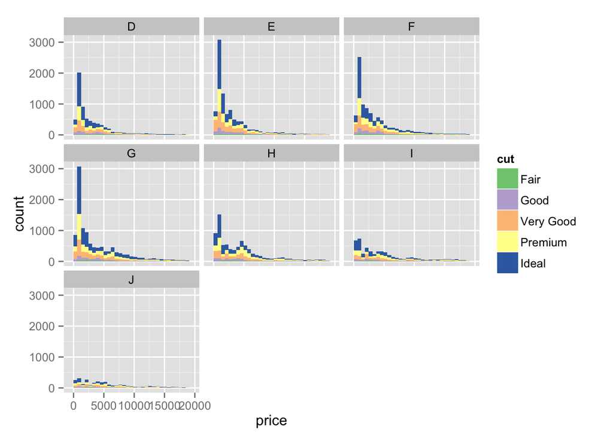

```r
library(ggplot2)
data(diamonds)

ggplot(aes(x=price),
       data = diamonds)+
  facet_wrap(~color)+
  geom_histogram(aes(fill=cut))+
  scale_fill_brewer(type='qual')
```

Create a scatterplot of diamond price vs. table and color the points by the cut of the diamond.

The plot should look something like this. http://i.imgur.com/rQF9jQr.jpg

Note: In the link, a color palette of type ‘qual’ was used to color the scatterplot using scale_color_brewer(type = ‘qual’)

```r
str(diamonds)
```

```
## 'data.frame':    53940 obs. of  10 variables:
##  $ carat  : num  0.23 0.21 0.23 0.29 0.31 0.24 0.24 0.26 0.22 0.23 ...
##  $ cut    : Ord.factor w/ 5 levels "Fair"<"Good"<..: 5 4 2 4 2 3 3 3 1 3 ...
##  $ color  : Ord.factor w/ 7 levels "D"<"E"<"F"<"G"<..: 2 2 2 6 7 7 6 5 2 5 ...
##  $ clarity: Ord.factor w/ 8 levels "I1"<"SI2"<"SI1"<..: 2 3 5 4 2 6 7 3 4 5 ...
##  $ depth  : num  61.5 59.8 56.9 62.4 63.3 62.8 62.3 61.9 65.1 59.4 ...
##  $ table  : num  55 61 65 58 58 57 57 55 61 61 ...
##  $ price  : int  326 326 327 334 335 336 336 337 337 338 ...
##  $ x      : num  3.95 3.89 4.05 4.2 4.34 3.94 3.95 4.07 3.87 4 ...
##  $ y      : num  3.98 3.84 4.07 4.23 4.35 3.96 3.98 4.11 3.78 4.05 ...
##  $ z      : num  2.43 2.31 2.31 2.63 2.75 2.48 2.47 2.53 2.49 2.39 ...
```

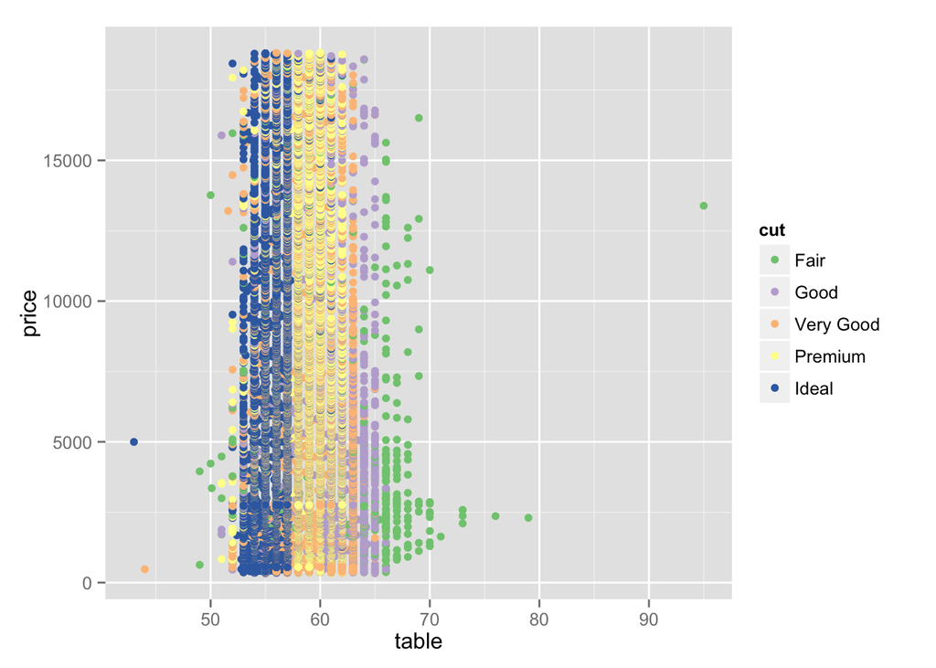

```r
ggplot(aes(x=table,y=price),
       data = diamonds)+
  geom_point(aes(color=cut))+
  scale_color_brewer(type='qual')
```

The discrete will shows that ideal 53-57, premium 58-62

Create a scatterplot of diamond price vs. volume (x * y * z) and color the points by the clarity of diamonds. Use scale on the y-axis to take the log10 of price. You should also omit the top 1% of diamond volumes from the plot.

Note: Volume is a very rough approximation of a diamond’s actual volume.

The plot should look something like this. http://i.imgur.com/excUpea.jpg

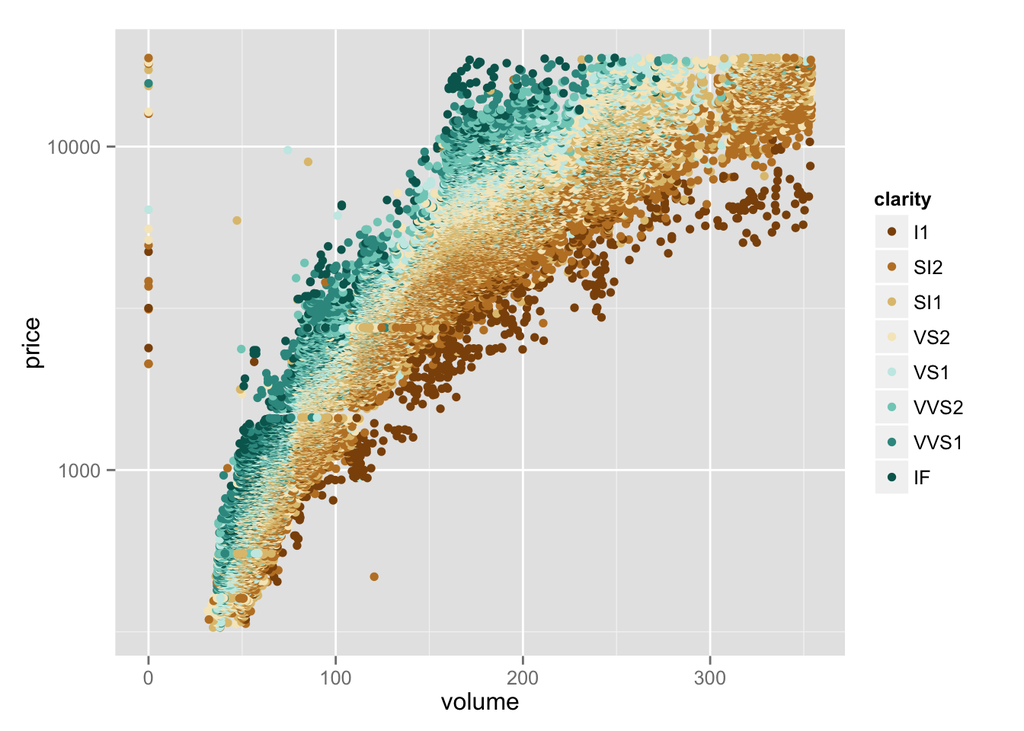

```r
diamonds <- transform(diamonds,volume=x*y*z)
ggplot(aes(x=volume,y=price),
       data=diamonds)+
  geom_point(aes(color=clarity))+
  scale_y_log10()+
  xlim(0,quantile(diamonds$volume,0.99))+
  scale_color_brewer(type='div')
```

Many interesting variables are derived from two or more others. For example, we might wonder how much of a person’s network on a service like Facebook the user actively initiated. Two users with the same degree (or number of friends) might be very different if one initiated most of those connections on the service, while the other initiated very few. So it could be useful to consider this proportion of existing friendships that the user initiated. This might be a good predictor of how active a user is compared with their peers, or other traits, such as personality (i.e., is this person an extrovert?).

Your task is to create a new variable called ‘prop_initiated’ in the Pseudo-Facebook data set. The variable should contain the proportion of friendships that the user initiated.

```r
pf <- read.csv('../lesson3/pseudo_facebook.tsv',sep='\t')
names(pf)
```

```
##  [1] "userid"                "age"
##  [3] "dob_day"               "dob_year"
##  [5] "dob_month"             "gender"
##  [7] "tenure"                "friend_count"
##  [9] "friendships_initiated" "likes"
## [11] "likes_received"        "mobile_likes"
## [13] "mobile_likes_received" "www_likes"
## [15] "www_likes_received"
```

```r
pf <- transform(pf, prop_initiated=friendships_initiated/friend_count)
```

Create a line graph of the proportion of friendships initiated (‘prop_initiated’) vs. tenure and color the line segment by year_joined.bucket.

Recall, we created year_joined.bucket in Lesson 5 by first creating year_joined from the variable tenure. Then, we used the cut function on year_joined to create four bins or cohorts of users.

(2004, 2009] (2009, 2011] (2011, 2012] (2012, 2014]

```r
pf <- transform(pf,year_joined=floor(2014-tenure/365))
pf <- transform(pf, year_joined.bucket = cut(year_joined,c(2004,2009,2011,2012,2014)))
table(pf$year_joined.bucket)
```

```
##
## (2004,2009] (2009,2011] (2011,2012] (2012,2014]
##        6669       15308       33366       43658
```

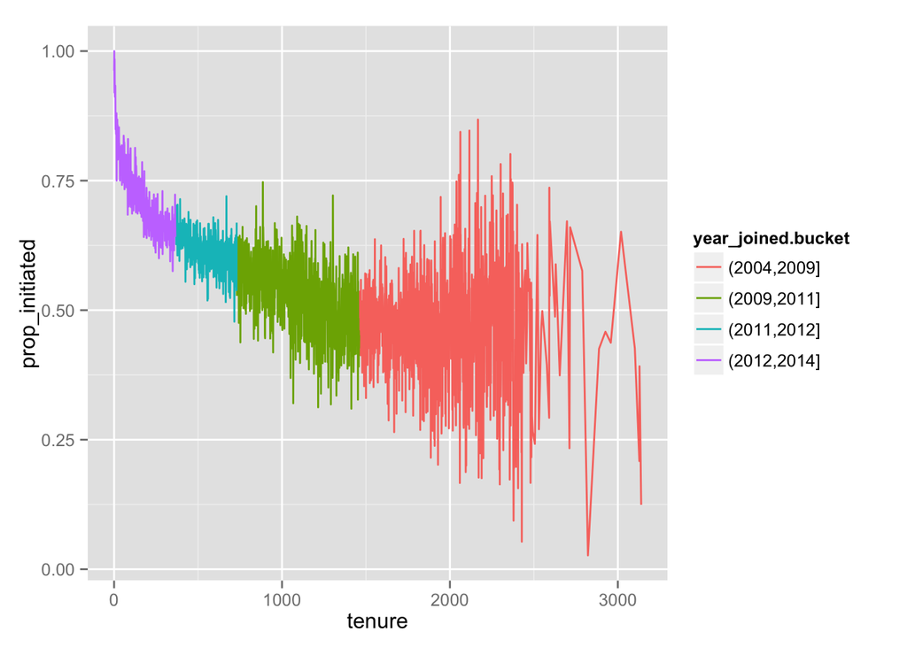

```r
ggplot(aes(x=tenure,y=prop_initiated),
       data=pf)+
  geom_line(aes(color=year_joined.bucket),
            stat="summary",
            fun.y = median)
```

Smooth the last plot you created of of prop_initiated vs tenure colored by year_joined.bucket. You can use larger bins for tenure or add a smoother to the plot.

There won’t be a solution image for this exercise. You will answer some questions about your plot in the next two exercises.

```
## geom_smooth: method="auto" and size of largest group is >=1000, so using gam with formula: y ~ s(x, bs = "cs"). Use 'method = x' to change the smoothing method.
```

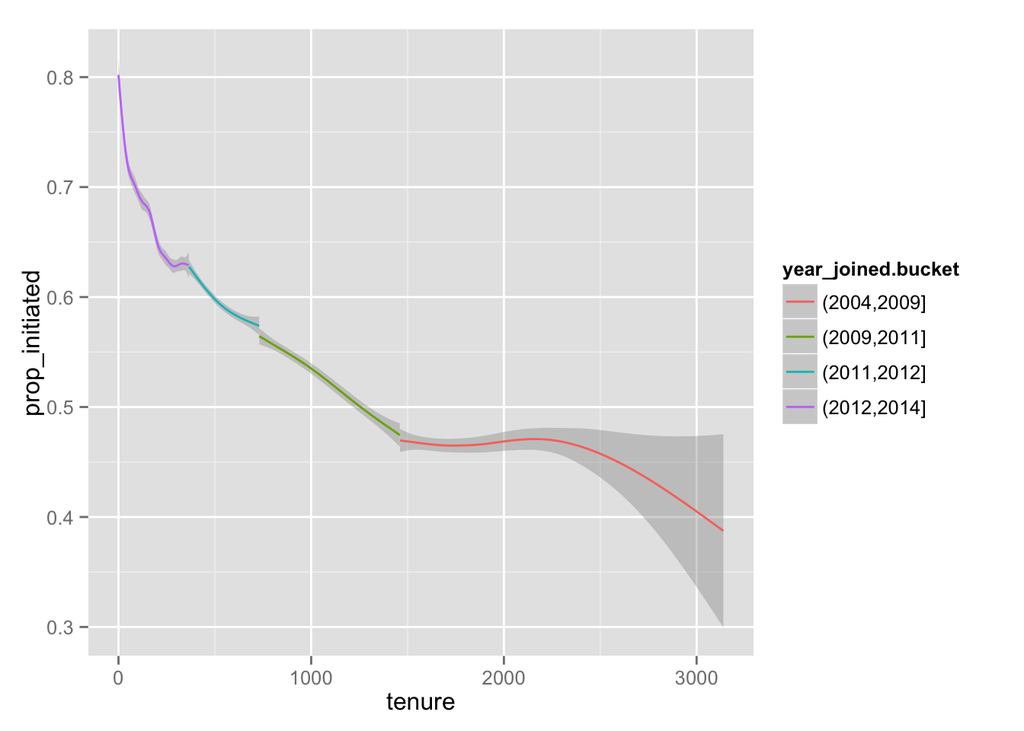

```r
ggplot(aes(x=tenure,y=prop_initiated),
       data=pf)+
  geom_smooth(aes(color=year_joined.bucket))
```

```r
summary(pf$year_joined.bucket)
```

```
## (2004,2009] (2009,2011] (2011,2012] (2012,2014]        NA's
##        6669       15308       33366       43658           2
```

```r
summary(subset(pf,year_joined.bucket == '(2012,2014]')$prop_initiated)
```

```
##    Min. 1st Qu.  Median    Mean 3rd Qu.    Max.    NA's
##  0.0000  0.5115  0.7018  0.6654  0.8490  1.0000    1468
```

- Because people with late join, tends to have friends that already on facebook. So they’re catching up by invite their friends
- When they first join, they were asked to invite friends that they do know, instead earlier when facebook didn’t implement such system.
- Facebook has become very famous, and sort of de facto standard for social network. Nonetheless, people (must) use facebook for engaging their network
- Like google, many apps nowadays in smartphone using facebook account to quickly login into their account.

Create a scatter plot of the price/carat ratio of diamonds. The variable x should be assigned to cut. The points should be colored by diamond color, and the plot should be faceted by clarity.

The plot should look something like this. http://i.imgur.com/YzbWkHT.jpg.

Note: In the link, a color palette of type ‘div’ was used to color the histogram using scale_color_brewer(type = ‘div’)

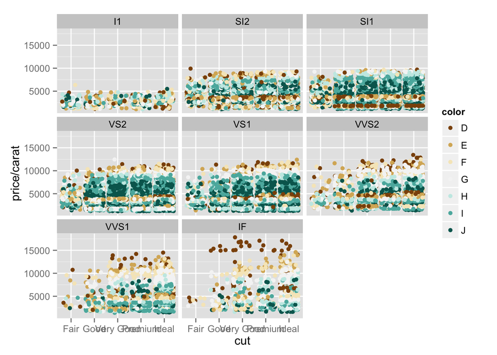

```r
ggplot(aes(x=cut, y = price/carat),
       data=diamonds)+
  geom_jitter(aes(color=color))+
  facet_wrap(~clarity)+
  scale_color_brewer(type='div')
```

Extract only ASEAN data from the dataset create bucket year ~1900,1900-1990,1990-2000,2000-2005 Create time series for the data. Mean Age at first mariage of women

```r
library(dplyr)
```

[output not shown]

[output not shown]

[output not shown]

[output not shown]

[output not shown]

[output not shown]

[output not shown]

[output not shown]

[output not shown]

[output not shown]

[output not shown]

[output not shown]

[output not shown]

[output not shown]

[output not shown]

[output not shown]

[output not shown]

[output not shown]

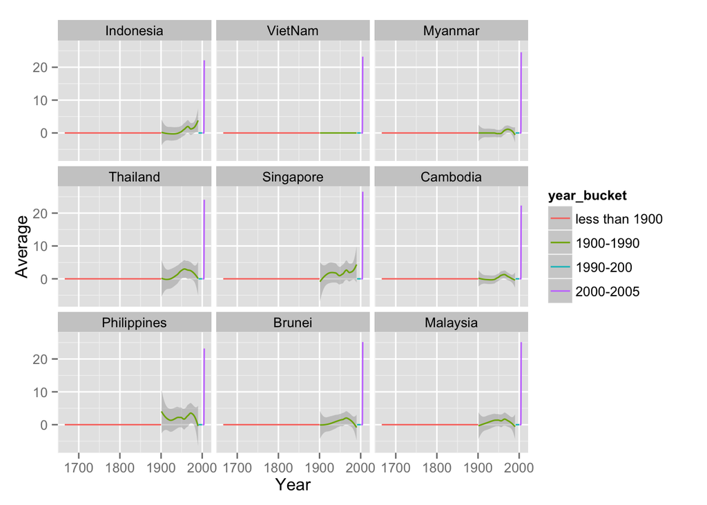

```r
wm <- read.csv('indicator age of marriage.csv')

ASEAN <- c('Indonesia','VietNam', 'Myanmar','Thailand','Singapore',
           'Cambodia','Philippines','Brunei','Malaysia')
bucket_year <- c(1616,1900,1990,2000,2005)
wm_asean <- filter(wm,X %in% ASEAN )
wm_asean <- transform(wm_asean, X=factor(X,ASEAN))
colnames(wm_asean) <- as.numeric(substr(colnames(wm_asean),start=2,stop=5))
colnames(wm_asean)[1] <- 'country'
library(reshape2)
wm_asean.long <- melt(wm_asean,
                      id='country',
                      value.name='Average',
                      variable.name = 'Year',
                      measure.vars=colnames(wm_asean)[-1])
wm_asean.long$Year <- as.numeric(as.character(wm_asean.long$Year))
wm_asean.long$Average[is.na(wm_asean.long$Average)] <- 0
wm_asean.long$year_bucket <- cut(wm_asean.long$Year,
                   breaks= bucket_year,
                   labels=c('less than 1900',
                        '1900-1990',
                        '1990-200',
                        '2000-2005'))

ggplot(aes(x=Year,y=Average),
       data=wm_asean.long)+
  geom_smooth(aes(color=year_bucket))+
  facet_wrap(~country)+
  ggsave('fmasean.jpg')
```